# **STACK**

### **Konversi Bilangan**

Pada dunia ilmu komputer seringkali dibutuhkan proses konversi dari suatu bilangan ke bilangan lain, misalkan dari bilangan desimal menjadi bilangan biner atau menjadi bilangan octal. Ilustrasi proses konversi dari bilangan desimal ke bilangan biner dapat dilihat pada Gambar 4 berikut.

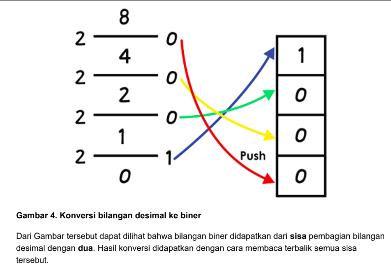

### **Latihan - 2**

Buat function untuk mengkonversi bilangan desimal menjadi bilangan biner dengan menggunakan konsep stack

```python
def desimal_ke_biner(desimal):
    # Menangani kasus khusus jika input adalah 0
    if desimal == 0:
        return "0"

    stack = []

    # Langkah 1: Push sisa bagi ke dalam stack
    while desimal > 0:
        sisa_bagi = desimal % 2
        stack.append(sisa_bagi) # Push ke stack
        desimal = desimal // 2  # Pembagian bulat dengan 2

    hasil_biner = ""

    # Langkah 2: Pop elemen dari stack untuk membentuk string biner
    while len(stack) > 0:
        hasil_biner += str(stack.pop()) # Pop dari stack

    return hasil_biner

# --- Contoh Penggunaan ---
angka = 25
print(f"Bilangan desimal: {angka}")
print(f"Bilangan biner  : {desimal_ke_biner(angka)}")
```

### **Ekspressi Aritmatik Infix, Prefix, Postfix**

Eksperssi aritmatik yang sering ditemui adalah operasi aritmatik **infix.** Pada operasi aritmatik **infix** ini, **operator** (+,-,*,/, dll) berada diantara dua buah **operand** (bilangan). Ekspressi aritmatik ini dapat dengan mudah diselesaikan ketika tidak ada ambiguitas, seperti:

A + B

A ∗ X

A − B + C

Akan tetapi, ekspressi aritmatik ini akan sulit diselesaikan jika terjadi ambiguitas, seperti ekspressi aritmatik berikut ini:

A + B ∗ C

Pada ekspressi tersebut, terdapat ambiguitas, yaitu apakah A + B diselesaikan terlebih dahulu ataukah B * C yang harus diselesaikan terlebih dahulu. Ambiguitas ini dapat diatasi dengan konsep **operator precedence.** Pada operator precedence, operator-operator dibagi menjadi beberapa level berdasarkan prioritas urutan penyelesaian.

Pada contoh ekspressi aritmatik A + B * C, berdasarkan operator precedence, maka urutan penyelesaian adalah B * C kemudian hasilnya ditambahkan dengan A. Permasalahan terjadi ketika pada ekspressi aritmatik A + B * C, A + B ingin diselesaikan terlebih dahulu. Untuk penyelesaian ekspressi aritmatik yang tidak sesuai dengan urutan operator precedence, maka tanda '( )' sangatlah diperlukan, sehingga operasi tersebut menjadi (A + B) * C.

Tanda '( )' **tidaklah diperlukan** pada ekspressi aritmatik **prefix** dan **postfix.** Pada ekspressi aritmatik **prefix,** operator mendahului operand, sedangkankan ekspressi aritmatik postfix, operator ditulis setelah operand.

Berikut contoh ekspressi aritmatik infix dan konversinya ke prefix dan postfix.

Infix Prefix Postfix

A*B-C*D -*AB*CD AB*CD*-

### Konversi Infix ke Postfix

Berikut algoritma untuk konversi ekspressi aritmatik infix ke postfix :

1. Buat struktur data stack untuk menampung operator
2. Baca ekspressi aritmatik dari kiri ke kanan tiap token :
- jika token yang dibaca adalah operand maka masukkan operand tersebut ke dalam output string
- jika token yang dibaca adalah kurung buka maka push kurung buka tersebut ke dalam stack
- jika token yang dibaca adalah kurang tutup maka pop stack semua token sampai ditemukan kurung buka
- jika token yang dibaca adalah operator maka :
  - pop operator-operator yang memiliki precedence lebih tinggi atau sama dan masukkan operator tersebut ke dalam output string
  - push token operator ke dalam stack
3. Jika masih terdapat operator pada stack, maka pop operator yang tersisa dan letakkan pada output string

[figure not shown]

### **Latihan - 3**

Buat function untuk mengkonversikan ekspressi aritmatik infix menjadi ekspressi aritmatik postfix

```python
def infix_ke_postfix(ekspresi):
    # Menentukan tingkat prioritas operator
    prioritas = {'+': 1, '-': 1, '*': 2, '/': 2, '^': 3}

    stack = []      # Stack untuk menyimpan operator
    postfix = []    # List untuk menyimpan hasil postfix

    # Menghilangkan spasi untuk mempermudah pembacaan karakter
    ekspresi = ekspresi.replace(" ", "")

    for karakter in ekspresi:
        # 1. Jika karakter adalah operand (huruf atau angka), langsung masukkan ke hasil
        if karakter.isalnum():
            postfix.append(karakter)

        # 2. Jika karakter kurung buka, masukkan ke stack
        elif karakter == '(':
            stack.append(karakter)

        # 3. Jika karakter kurung tutup, keluarkan operator dari stack sampai ketemu kurung buka
        elif karakter == ')':
            while stack and stack[-1] != '(':
                postfix.append(stack.pop())
            stack.pop() # Buang kurung buka '(' dari stack

        # 4. Jika karakter adalah operator (+, -, *, /, ^)
        else:
            # Selama stack tidak kosong, elemen teratas bukan '(', dan
            # prioritas operator saat ini <= prioritas operator di puncak stack
            while (stack and stack[-1] != '(' and
                   prioritas.get(karakter, 0) <= prioritas.get(stack[-1], 0)):
                postfix.append(stack.pop())
            # Masukkan operator saat ini ke stack
            stack.append(karakter)

    # 5. Keluarkan semua sisa operator di dalam stack ke hasil
    while stack:
        postfix.append(stack.pop())

    return "".join(postfix)

# --- Contoh Penggunaan ---
ekspresi_infix = "A + B * (C - D)"
hasil_postfix = infix_ke_postfix(ekspresi_infix)

print(f"Ekspresi Infix   : {ekspresi_infix}")
print(f"Ekspresi Postfix : {hasil_postfix}")
```

```
Ekspresi Infix   : A + B * (C - D)
Ekspresi Postfix : ABCD-*+
```

### **Evaluasi Ekspressi Postfix**

Seperti yang sudah dijelaskan sebelumnya, evaluasi untuk ekspressi aritmatika Postfix dilakukan setelah terdapat dua buah operand sebelum sebuah operator. Misalkan : 87+2*, yang berarti (8+7)*2=30, oleh karena itu berikut algoritma untuk mengevaluasi ekspressi aritmatika postfix :

1. baca string mulai dari kiri
2. Jika character yang dibaca adalah sebuah operand, maka push operand tersebut.
3. Jika character yang dibaca adalah sebuah operator, maka pop dua buah operand yang terdapat pada stack, operasikan dua buah operand tersebut dengan operator, dan push hasil operasinya
4. hasil akhir adalah angka terakhir yang terdapat di dalam stack

**Code**

Berikut code untuk evaluasi ekspressi postfix

```python
def evaluatePost(postStr):
    operandStack=stack()
    operator='+-/*'
    for i in postStr:
        if i not in operator:
            push(operandStack,i)
        else:
            oprnd2=pop(operandStack)
            oprnd1=pop(operandStack)
            if i=='+':
                result=float(oprnd1)+float(oprnd2)
            elif i=='-':
                result=float(oprnd1)-float(oprnd2)
            elif i=='*':
                result=float(oprnd1)*float(oprnd2)
            else:
                result=float(oprnd1)/float(oprnd2)
            push(operandStack,result)
    return(pop(operandStack))

print(evaluatePost('45-6*'))
```

## **STACK W3**

Stack adalah struktur data linier yang mengikuti prinsip Last-In-First-Out (LIFO).

Bayangkan seperti tumpukan pancake - Anda hanya bisa menambah atau mengurangi pancake dari bagian atas.

### **Tumpukan**

Stack adalah struktur data yang dapat menampung banyak elemen, dan elemen terakhir yang ditambahkan adalah elemen pertama yang dihapus.

Seperti tumpukan pancake, pancake ditambahkan dan dikeluarkan dari atas. Jadi, ketika mengeluarkan pancake, itu selalu pancake terakhir yang Anda tambahkan. Cara mengatur elemen seperti ini disebut LIFO: Last In First Out (Terakhir Masuk, Pertama Keluar).

Operasi dasar yang dapat kita lakukan pada sebuah stack adalah:

- **Push:** Menambahkan elemen baru ke dalam tumpukan.
- **Pop:** Menghapus dan mengembalikan elemen teratas dari tumpukan.
- **Peek:** Mengembalikan elemen teratas (terakhir) pada tumpukan.
- **isEmpty:** Memeriksa apakah tumpukan kosong.
- **Ukuran:** Menemukan jumlah elemen dalam tumpukan.

Stack dapat diimplementasikan dengan menggunakan array atau linked list.

Stack dapat digunakan untuk mengimplementasikan mekanisme undo, untuk kembali ke keadaan sebelumnya, untuk membuat algoritma pencarian mendalam (depth-first search) dalam graf, atau untuk penelusuran balik (backtracking).

Stack sering disebut bersamaan dengan Queue, yang merupakan struktur data serupa yang dijelaskan pada halaman berikutnya.

**Implementasi Stack menggunakan List Python**

Untuk daftar (dan array) Python, sebuah tumpukan dapat terlihat dan berperilaku seperti ini:

x = [5, 6, 2, 9, 3, 8, 4, 2]

Menambahkan:**push**

Menghapus:**pop**

Karena list Python memiliki dukungan yang baik untuk fungsionalitas yang dibutuhkan untuk mengimplementasikan stack, kita mulai dengan membuat stack dan melakukan operasi stack hanya dengan beberapa baris seperti ini:

```python
#Contoh Menggunakan list Python sebagai stack:

stack = []

# Push
stack.append('A')
stack.append('B')
stack.append('C')
print("Stack: ", stack)

# Peek
topElement = stack[-1]
print("Peek: ", topElement)

# Pop
poppedElement = stack.pop()
print("Pop: ", poppedElement)

# Stack after Pop
print("Stack after Pop: ", stack)

# isEmpty
isEmpty = not bool(stack)
print("isEmpty: ", isEmpty)

# Size
print("Size: ",len(stack))
```

Meskipun list Python dapat digunakan sebagai stack, membuat kelas Stack khusus memberikan enkapsulasi yang lebih baik dan fungsionalitas tambahan:

```python
# Contoh Membuat tumpukan menggunakan kelas:

class Stack:
  def __init__(self):
    self.stack = []

  def push(self, element):
    self.stack.append(element)

  def pop(self):
    if self.isEmpty():
      return "Stack is empty"
    return self.stack.pop()

  def peek(self):
    if self.isEmpty():
      return "Stack is empty"
    return self.stack[-1]

  def isEmpty(self):
    return len(self.stack) == 0

  def size(self):
    return len(self.stack)

# Create a stack
myStack = Stack()

myStack.push('A')
myStack.push('B')
myStack.push('C')

print("Stack: ", myStack.stack)
print("Pop: ", myStack.pop())
print("Stack after Pop: ", myStack.stack)
print("Peek: ", myStack.peek())
print("isEmpty: ", myStack.isEmpty())
print("Size: ", myStack.size())
```

Alasan untuk mengimplementasikan stack menggunakan list/array:

- **Efisien Memori:** Elemen array tidak menyimpan alamat elemen berikutnya seperti halnya node pada linked list.
- **Lebih mudah diimplementasikan dan dipahami:** Menggunakan array untuk mengimplementasikan stack membutuhkan lebih sedikit kode daripada menggunakan linked list, dan karena alasan ini biasanya juga lebih mudah dipahami.

Alasan mengapa array tidak digunakan untuk mengimplementasikan stack:

- **Ukuran tetap:** Sebuah array menempati bagian memori yang tetap. Ini berarti bahwa array tersebut dapat menggunakan lebih banyak memori daripada yang dibutuhkan, atau jika array penuh, array tersebut tidak dapat menampung elemen lagi.

**Implementasi Stack menggunakan Linked List**

Sebuah linked list terdiri dari node yang berisi data tertentu, dan sebuah pointer ke node berikutnya.

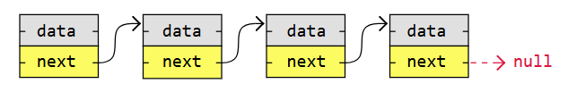

Salah satu keuntungan besar menggunakan linked list adalah node disimpan di mana pun ada ruang kosong di memori, node tidak perlu disimpan berdekatan satu sama lain seperti elemen yang disimpan dalam array. Keuntungan lain dari linked list adalah ketika menambahkan atau menghapus node, node lain dalam list tidak perlu digeser.

Untuk lebih memahami manfaat menggunakan array atau linked list untuk mengimplementasikan stack, Anda sebaiknya memeriksa halaman ini yang menjelaskan bagaimana array dan linked list disimpan dalam memori.

Beginilah cara mengimplementasikan stack menggunakan linked list.

```python
#Contoh Membuat Stack menggunakan Linked List:

class Node:
  def __init__(self, value):
    self.value = value
    self.next = None

class Stack:
  def __init__(self):
    self.head = None
    self.size = 0

  def push(self, value):
    new_node = Node(value)
    if self.head:
      new_node.next = self.head
    self.head = new_node
    self.size += 1

  def pop(self):
    if self.isEmpty():
      return "Stack is empty"
    popped_node = self.head
    self.head = self.head.next
    self.size -= 1
    return popped_node.value

  def peek(self):
    if self.isEmpty():
      return "Stack is empty"
    return self.head.value

  def isEmpty(self):
    return self.size == 0

  def stackSize(self):
    return self.size

  def traverseAndPrint(self):
    currentNode = self.head
    while currentNode:
      print(currentNode.value, end=" -> ")
      currentNode = currentNode.next
    print()

myStack = Stack()
myStack.push('A')
myStack.push('B')
myStack.push('C')

print("LinkedList: ", end="")
myStack.traverseAndPrint()
print("Peek: ", myStack.peek())
print("Pop: ", myStack.pop())
print("LinkedList after Pop: ", end="")
myStack.traverseAndPrint()
print("isEmpty: ", myStack.isEmpty())
print("Size: ", myStack.stackSize())
```

Alasan menggunakan linked list untuk mengimplementasikan stack:

- **Ukuran dinamis:** Stack dapat tumbuh dan menyusut secara dinamis, tidak seperti pada array. Alasan mengapa linked list **tidak** digunakan untuk mengimplementasikan stack:
- **Memori tambahan:** Setiap elemen tumpukan harus berisi alamat ke elemen berikutnya (node daftar tertaut berikutnya).
- **Keterbacaan:** Kode ini mungkin lebih sulit dibaca dan ditulis bagi sebagian orang karena lebih panjang dan lebih kompleks.

**Aplikasi Tumpukan Umum**

Stack digunakan dalam banyak skenario dunia nyata:

- Operasi Undo/Redo di editor teks
- Riwayat browser (mundur/maju)
- Tumpukan panggilan fungsi dalam pemrograman
- Evaluasi ekspresi

## **Stack di Pyhton GFG**

Stack adalah struktur data linier yang mengikuti prinsip Last-In/First-Out (LIFO), juga dikenal sebagai First-In/Last-Out (FILO). Ini berarti bahwa elemen terakhir yang ditambahkan adalah elemen pertama yang dihapus. Dalam sebuah stack, baik penyisipan maupun penghapusan terjadi di ujung yang sama, yang disebut puncak stack.

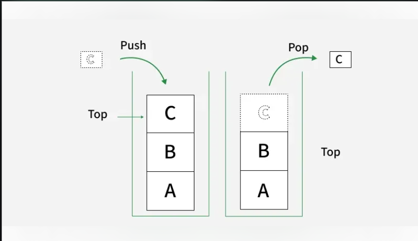

Python tidak memiliki tipe data stack bawaan, tetapi stack dapat diimplementasikan dengan berbagai cara menggunakan struktur data yang berbeda. Mari kita lihat beberapa implementasinya:

**1. Menggunakan Daftar**

- List Python menyediakan metode bawaan yang membuatnya cocok untuk operasi stack.
- Metode append () menambahkan elemen ke akhir daftar.
- Metode pop() menghapus dan mengembalikan elemen terakhir dari daftar.

Operasi-operasi ini memungkinkan sebuah list untuk secara langsung mendukung perilaku seperti stack.

```python
stack = []

# append() function to push element in the stack
stack.append('a')
stack.append('b')
stack.append('c')

print('Initial stack')
print(stack)
# pop() function to pop element from stack in LIFO order
print('\nElements popped from stack:')
print(stack.pop())
print(stack.pop())
print(stack.pop())

print('\nStack after elements are popped:')
print(stack)

# uncommenting print(stack.pop()) will cause an IndexError as the stack is now empty
# Daftar dapat melambat ketika ukurannya menjadi sangat besar karena alokasi ulang memori.
```

**2. Menggunakan collections.deque**

- Modul collections Python menyediakan deque (antrian dua ujung) untuk penyisipan dan penghapusan yang efisien.
- Metode append () menambahkan elemen ke ujung kanan deque.
- Metode pop() menghapus dan mengembalikan elemen dari ujung kanan.
- Karena deque dioptimalkan untuk penambahan dan penghapusan data yang cepat, deque seringkali lebih disukai daripada list untuk implementasi stack.

```python
from collections import deque
stack = deque()

# append() function to push element in the stack
stack.append('a')
stack.append('b')
stack.append('c')

print('Initial stack:')
print(stack)

# pop() function to pop element from stack in LIFO order
print('\nElements popped from stack:')
print(stack.pop())
print(stack.pop())
print(stack.pop())

print('\nStack after elements are popped:')
print(stack)

# uncommenting print(stack.pop()) will cause an IndexError as the stack is now empty
```

# **LATIHAN SOAL STACK**

**1. Prinsip utama yang digunakan oleh struktur data Stack adalah...**

A. FIFO (First In First Out)

B. LIFO (Last In First Out)

C. Random Access

D. Priority Based

**2. Metode Python mana yang paling umum digunakan untuk mensimulasikan operasi 'push' pada sebuah list?**

A. insert()

B. add()

C. append()

D. push()

**3. Untuk menghapus elemen terakhir dari stack (operasi 'pop') di Python menggunakan list, kita menggunakan fungsi...**

A. remove()

B. delete()

C. pop()

D. discard()

**4. Apa output dari kode berikut?**

stack = [10, 20, 30] stack.append(40) stack.pop() print(stack)

A. [10, 20, 30, 40]

B. [10, 20, 30]

C. [20, 30, 40]

D. [10, 20]

**5. Kondisi 'Stack Underflow' terjadi ketika...**

A. Menambahkan elemen ke stack yang sudah penuh.

B. Menghapus elemen dari stack yang kosong.

C. Mengakses elemen di tengah stack.

D. Stack memiliki terlalu banyak elemen.

**6. Manakah dari modul berikut yang menyediakan deque untuk implementasi stack yang lebih efisien?**

A. math

B. collections

C. random

D. sys

**7. Operasi 'peek' pada stack bertujuan untuk...**

A. Menghapus elemen teratas.

B. Melihat elemen teratas tanpa menghapusnya.

C. Menghitung jumlah elemen dalam stack.

D. Mengosongkan seluruh isi stack.

**8. Bagaimana cara melakukan operasi 'peek' pada list Python bernama s yang digunakan sebagai stack?**

A. s[0]

B. s.peek()

C. s[-1]

D. s.top()

**9. Manakah dari aplikasi berikut yang merupakan contoh nyata penggunaan Stack?**

A. Penjadwalan printer.

B. Fungsi Undo/Redo pada editor teks.

C. Antrean di loket bank.

D. Pemutaran playlist musik secara berurutan.

**10. Jika dilakukan operasi: push(1), push(2), pop(), push(3), pop() pada stack kosong, apa elemen yang tersisa?**

A. [1, 2, 3]

B. [1]

C. [3]

D. Stack kosong

**11. Cara paling Pythonic untuk memeriksa apakah sebuah stack (list) kosong adalah...**

A. if stack == empty:

B. if not stack:

C. if stack.is_empty():

D. if stack.size == 0:

**12. Apa yang terjadi jika Anda menjalankan [].pop() (pop pada list kosong) di Python?**

A. Mengembalikan None.

B. Mengembalikan 0.

C. Menghasilkan IndexError.

D. Program berhenti tanpa pesan error.

**13. Balik Kata (String Reversal): Masukkan sebuah string (misal: "PYTHON") dan gunakan stack untuk menghasilkan output terbalik ("NOHTYP").**

```python
def reverse_string_func(text):
    stack = []
    for char in text:
        stack.append(char)

    reversed_text = ""
    while len(stack) > 0:
        reversed_text += stack.pop()
    return reversed_text

print(reverse_string_func("JUPYTER"))
```

**14. Pengecek Tanda Kurung (Parentheses Checker): Buat fungsi untuk mengecek apakah urutan tanda kurung seimbang. Contoh: (()) adalah valid, sedangkan (() tidak valid.**

```python
class Stack:
    def __init__(self): self.items = []
    def push(self, item): self.items.append(item)
    def pop(self): return self.items.pop()
    def is_empty(self): return len(self.items) == 0

def check_with_class(text):
    s = Stack()
    for char in text:
        if char == '(': s.push(char)
        elif char == ')':
            if s.is_empty(): return False
            s.pop()
    return s.is_empty()
```

**15. Konversi Desimal ke Oktal (Basis 8): Mirip dengan contoh biner, namun pembaginya adalah 8.**

```python
def convert_full(n):
    stack = []
    while n > 0:
        stack.append(n % 8)
    res = ""
    while len(stack) > 0: # size check
        res += str(stack.pop())
    return res
```

**16. Fitur Back Navigasi: Simulasikan riwayat browser sederhana. Setiap kali mengunjungi URL baru, "push" ke stack. Gunakan fungsi "back" untuk "pop" URL terakhir.**

```python
history = []
def browser_full():
    history.append("page1.com")
    history.append("page2.com")
    if len(history) > 0:
        print(f"Current page (Peek): {history[-1]}")
    history.pop()
    print(f"Back to: {history[-1]}")
```

**17. Menghapus Duplikat Berurutan: Hapus karakter yang sama jika muncul berdampingan. Misal: "aaabbcdd" menjadi "abcd" menggunakan logika stack.**

```python
def remove_duplicates(s):
    stack = []
    for char in s:
        if stack and stack[-1] == char:
            continue
        stack.append(char)
    return "".join(stack)

print(remove_duplicates("aaabbcdd")) # abcd
```

# **Latihan Pilgan**

Berikut adalah 5 soal latihan untuk menguji pemahaman konsep dasar Stack.

1. Operasi dalam Stack yang berfungsi untuk menambahkan elemen ke posisi paling atas disebut dengan...

A. Pop

B. Push

C. Peek

D. IsEmpty

**Jawaban: B (Push)** Penjelasan: Operasi Push digunakan untuk memasukkan data ke dalam tumpukan, sedangkan Pop digunakan untuk mengambil data dari tumpukan.

2. Stack mengikuti prinsip kerja yang dikenal dengan istilah...

A. FIFO (First In First Out)

B. LILO (Last In Last Out)

C. LIFO (Last In First Out)

D. FILO (First In Last Out)

**Jawaban: C (LIFO)** Penjelasan: Stack bersifat LIFO, artinya elemen yang terakhir dimasukkan adalah elemen yang pertama kali dikeluarkan.

3. Apa yang terjadi jika kita melakukan operasi pop() pada Stack yang kosong?

A. Program berhenti mendadak

B. Stack akan mereset ke nol

C. Terjadi kondisi Stack Underflow

D. Terjadi kondisi Stack Overflow

**Jawaban: C (Stack Underflow)**

Penjelasan: Stack Underflow terjadi ketika kita mencoba mengambil data dari tumpukan yang sudah tidak memiliki elemen.

4. Dalam implementasi Stack menggunakan list di Python, elemen yang dianggap sebagai "top" biasanya adalah...

A. Elemen pada indeks ke-0

B. Elemen terakhir pada list

C. Elemen tengah list

D. Tergantung pilihan user

**Jawaban: B (Elemen terakhir pada list)**

Penjelasan: Menggunakan elemen terakhir pada list sebagai top lebih efisien karena tidak memerlukan pergeseran indeks (shifting) seperti pada indeks ke-0.

5. Manakah dari pilihan berikut yang merupakan contoh penerapan nyata dari struktur data Stack?

A. Antrean cetak dokumen (Printer spooling)

B. Undo/Redo pada aplikasi teks editor

C. Navigasi file pada sistem operasi

D. Penjadwalan proses CPU

**Jawaban: B (Undo/Redo pada aplikasi teks editor)**

Penjelasan: Fitur Undo menyimpan aksi terakhir yang dilakukan, sehingga aksi tersebut dapat dibatalkan (diambil kembali) sesuai prinsip LIFO

# **LATIHAN CODE**

**Soal 1: Dasar Push & Pop**

Buatlah program yang menginisialisasi stack kosong, lakukan push 3 angka (10, 20, 30), lalu lakukan pop satu kali dan tampilkan isi stack terakhir.

```python
stack = []
# Push
stack.append(10)
stack.append(20)
stack.append(30)
# Pop
stack.pop()
print("Isi stack setelah pop:", stack)
```

**Soal 2: Fungsi Peek Manual**

Buatlah fungsi lihat_atas(stack) yang mengembalikan elemen teratas tanpa menghapusnya. Jika kosong, kembalikan pesan "Stack Kosong".

```python
def lihat_atas(stack):
    if not stack:
        return "Stack Kosong"
    return stack[-1]

s = [1, 2, 3]
print("Elemen atas:", lihat_atas(s))
```

**Soal 3: Membalikkan String**

Gunakan prinsip LIFO dari stack untuk membalikkan sebuah kata (contoh: "INFORMATIKA" menjadi "AKITAMROFNI").

```python
kata = "INFORMATIKA"
stack = list(kata)
reversed_kata = ""
while stack:
    reversed_kata += stack.pop()
print("Hasil balik:", reversed_kata)
```

**Soal 4: Menghitung Kedalaman Stack**

Buatlah program untuk menghitung berapa banyak elemen di dalam stack tanpa menggunakan fungsi len().

```python
stack = [10, 20, 30, 40]
count = 0
for i in stack:
    count += 1
print("Jumlah elemen:", count)
```

**Soal 5: Filter Genap**

Buatlah program yang mengambil semua elemen dari stack, lalu hanya memasukkan elemen genap ke dalam stack baru (stack_genap).

```python
stack = [1, 2, 3, 4, 5, 6]
stack_genap = []
while stack:
    val = stack.pop()
    if val % 2 == 0:
        stack_genap.append(val)
print("Stack genap:", stack_genap)
```

**Soal 6: Pengecekan Kurung Seimbang (Basic)**

Buatlah program sederhana untuk mengecek apakah sebuah string berisi kurung buka ( dan kurung tutup ) seimbang.

```python
teks = "((()))"
stack = []
seimbang = True
for char in teks:
    if char == '(':
        stack.append(char)
    elif char == ')':
        if not stack:
            seimbang = False
            break
        stack.pop()
print("Apakah seimbang?", seimbang and not stack)
```

**Soal 7: Mengosongkan Stack**

Buatlah fungsi kosongkan_stack(stack) yang terus melakukan pop sampai stack benar-benar kosong, dan cetak setiap elemen yang dihapus.

```python
def kosongkan_stack(stack):
    while stack:
        print("Menghapus:", stack.pop())
    print("Stack sekarang kosong.")

s = [1, 2, 3]
kosongkan_stack(s)
```

**Soal 8: Memindahkan Isi Stack**

Pindahkan semua elemen dari stack_a ke stack_b sehingga urutannya terbalik.

```python
stack_a = [1, 2, 3]
stack_b = []
while stack_a:
    stack_b.append(stack_a.pop())
print("Stack B:", stack_b)
```

**Soal 9: Mencari Nilai Maksimum**

Tanpa menggunakan fungsi max(), temukan nilai terbesar di dalam stack dengan melakukan pop satu per satu.

```python
stack = [15, 30, 10, 50, 5]
maks = -999
while stack:
    val = stack.pop()
    if val > maks:
        maks = val
print("Nilai maksimal:", maks)
```

**Soal 10: Stack Berisi Data User**

Buatlah stack yang menyimpan nama-nama mahasiswa, lalu buat sistem "Undo" yang menghapus nama terakhir yang di-input.

```python
database = ["Zaka", "Budi", "Siti"]
print("Sebelum undo:", database)
# Sistem Undo
if database:
    dihapus = database.pop()
    print(f"Undo dilakukan, {dihapus} dihapus.")
print("Sesudah undo:", database)
```